# PCA INTRODUCTION

Irene Knecht

1 July 2016

## PRINCIPAL COMPONENT ANALYSIS (PCA)

In the field of mathematics the PCA is known as the *principal axis theorem* or the *singular value decomposition*. Principal component analysis is a process of multivariate statistics.

Wikipedia explanation:

> “Principal component analysis (PCA) is a statistical procedure that uses an orthogonal transformation to convert a set of observations of possibly correlated variables into a set of values of linearly uncorrelated variables called principal components. The number of principal components is less than or equal to the number of original variables. This transformation is defined in such a way that the first principal component has the largest possible variance (that is, accounts for as much of the variability in the data as possible), and each succeeding component in turn has the highest variance possible under the constraint that it is orthogonal to the preceding components. The resulting vectors are an uncorrelated orthogonal basis set. The principal components are orthogonal because they are the eigenvectors of the covariance matrix, which is symmetric. PCA is sensitive to the relative scaling of the original variables.”

### DATA EXAMPLE

Here I show you an example how you can use the principal component analysis with R. We use the *iris* data frame which is a example from R itselfs. Now we load this data frame and use the *head()* function to have a first expression.

```r
data(iris)
head(iris)
```

```
##   Sepal.Length Sepal.Width Petal.Length Petal.Width Species
## 1          5.1         3.5          1.4         0.2  setosa
## 2          4.9         3.0          1.4         0.2  setosa
## 3          4.7         3.2          1.3         0.2  setosa
## 4          4.6         3.1          1.5         0.2  setosa
## 5          5.0         3.6          1.4         0.2  setosa
## 6          5.4         3.9          1.7         0.4  setosa
```

### PCA WITH FACTOMINER

The *FactoMineR* package was made from Fançois Husson. It is a R package for principal component analysis. François Husson has a YouTube channel where you can find [Videos showing how to perform PCA with FactoMineR](https://www.youtube.com/watch?v=CTSbxU6KLbM&list=PLnZgp6epRBbTsZEFXi_p6W48HhNyqwxIu&index=3).

Now let’s load the *FactoMineR* package into R.

```r
library(FactoMineR)
```

```r
PCA_iris <- PCA(iris,scale.unit=TRUE,quali.sup=5,graph=FALSE)
```

There are two important plots from PCA:

- the individuals factor map
- the variables factor map

Now I want to show them side by side.

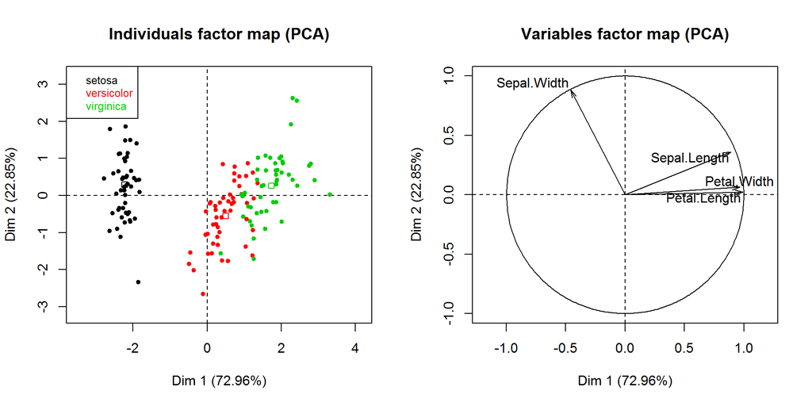

```r
# the plot should be layouted in one row and two columns
#(side by side)
par(mfrow=c(1,2))
# the individuals factor map
plot.PCA(PCA_iris,axes=c(1,2),choix="ind",habillage="Species",label="no")
# the variables factor map
plot.PCA(PCA_iris,axes=c(1,2),choix="var")
```

### PCA WITH FACTOEXTRA

The package *factoextra* is performing with the package *ggplot2*. You need both to make a principal component analysis with *factoextra*. To load the packages you have to use the *library()* function.

```r
library(ggplot2)
library(factoextra)
```

There are a lot of function included in *factoextra*. I recommend the *fviz_pca_biplot()* function, because it includes the individuals as well as the variables factor map.

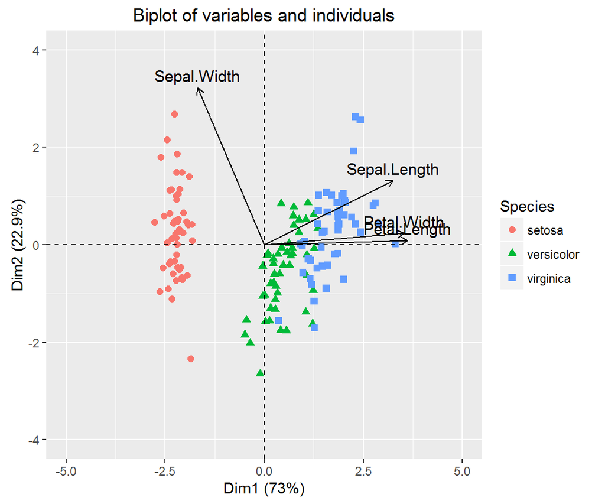

```r
fviz_pca_biplot(PCA_iris, choix="ind", habillage="Species", label="var", invisible="quali", col.var="black")+
  xlim(-5,5)+
  ylim(-4,4)
```

Now I just want to see the average of the *Species* groups in the PCA biplot.

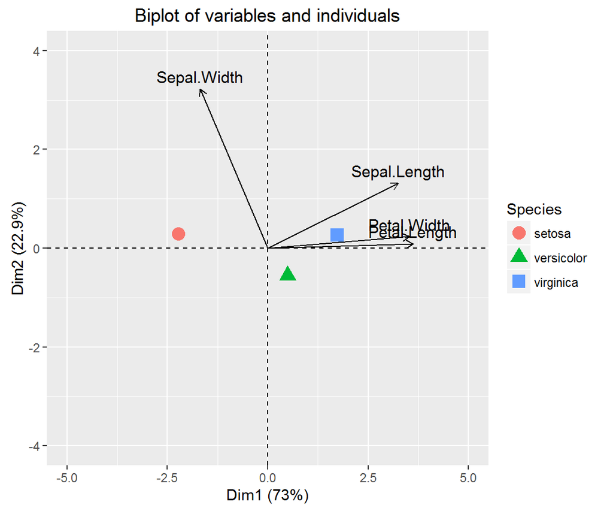

```r
fviz_pca_biplot(PCA_iris, choix="quali", habillage="Species", label="var", invisible="ind", col.var="black")+
  xlim(-5,5)+
  ylim(-4,4)
```

### LINEAR REGRESSION

We saw in the variables factor map that the arrows from the *Petal Width* and the *Petal Length* are very close. To see the correlation I make a plot with this two variables and add a trendline to the plot.

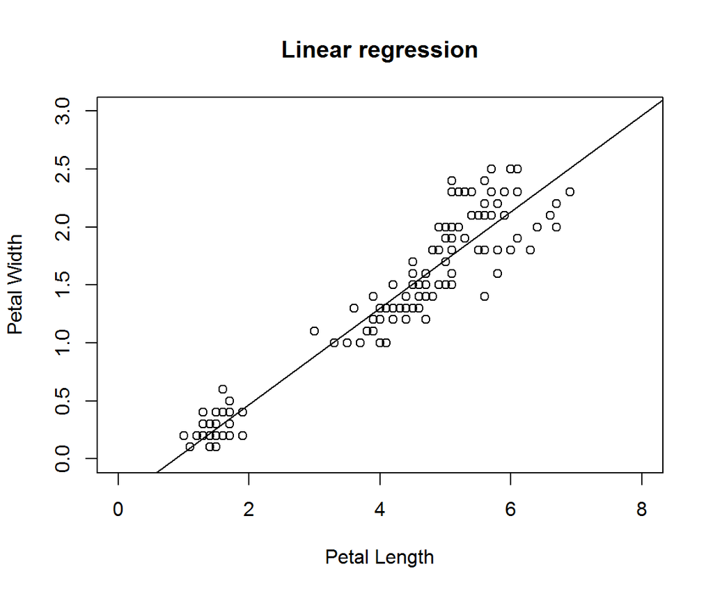

```r
par(mfrow=c(1,1))
plot(iris$Petal.Length,iris$Petal.Width,xlim=c(0,8), ylim=c(0,3), xlab="Petal Length", ylab="Petal Width", main="Linear regression")
abline(lm(Petal.Width~Petal.Length, iris))
```

… and we can have a look at the linear regression.

```r
lm(Petal.Width~Petal.Length, iris)
```

```
##
## Call:
## lm(formula = Petal.Width ~ Petal.Length, data = iris)
##
## Coefficients:
##  (Intercept)  Petal.Length
##      -0.3631        0.4158
```